# Data Wrangling of the NEISS-2024 Data

My most favorite functions in R are mutate() and select(). I believe them to be the foundation of any analytical approach. With mutate(), it offers a unique kind of flexibility, which allows me to reach out to other objects and variables to synthesize new summaries or craft temporary logic-gate variables right in the middle of a pipe. Meanwhile, select() is my go-to for structural precision, enabling me to rename columns while simultaneously filtering the dataset down to its most significant figures: select(new_name = old_name, column_name2, column_name3).

There are others, like adorn_totals(), count(name = 'new_name'), and pivot_wider(). These have been essential in creating summaries that make monitoring and reporting easier, but they also allow me to venture into learning questions in programming to maximize programmatic impact.

So, when I decided to take a stab at learning Python for data analytics and eventually data science, I went the "Tidy Way”: I replicated the steps I was already used to in R language. Two aspects of Python's pandas library fully drew me in:

1. Method Chaining (the equivalent to R’s piping) and
2. .assign() (the equivalent to R’s mutate()).

Once I established that, I realized the rest wouldn't be hard because data cleaning and preparation take up the biggest chunk of any analytical endeavor anyway.

To sharpen these skills, I am performing a data wrangling exercise on the National Electronic Injury Surveillance System (NEISS) 2024 data. This dataset is a puzzle of raw incident reports, encoded dictionaries, and format values. My goal is to clean this raw data so we can transform encoded noise into public safety insights.

# Data Import

Our analysis relies on three distinct datasets that, when bonded together, reveal the full story of national injury trends:

#### 1. NEISS-2024: This is our primary raw data containing over 360,000 individual emergency room cases, currently locked in a numerical shorthand.

```python
# Loading necessary libraries for importing and data wrangling
import pandas as pd
import janitor
import numpy as np
import matplotlib.pyplot as plt

# Setting the maximum column width to 'None' to have unlimited widith
pd.set_option('display.max_colwidth', None)

# Importing the neiss_2024 dataset for analysis
neiss_2024 = (
    pd.read_excel("D:/Personal/Projects/diagnosis/neiss2024.xlsx")
    .clean_names() # Standardizing the column names
)

# Previewing the head of the neiss_2024 to have a glimpse of the data
neiss_2024.head()
```

|  | cpsc_case_number | treatment_date | age | sex | race | other_race | hispanic | body_part | diagnosis | other_diagnosis | ... | fire_involvement | product_1 | product_2 | product_3 | alcohol | drug | narrative_1 | stratum | psu | weight |
| --- | --- | --- | --- | --- | --- | --- | --- | --- | --- | --- | --- | --- | --- | --- | --- | --- | --- | --- | --- | --- | --- |
| 0 | 240108461 | 2024-01-01 | 16 | 1 | 0 | NaN | 1 | 30 | 64 | NaN | ... | 0 | 1267 | 0 | 0 | 0 | 0 | 16YOM PLAYING SOCCER, HURT HIS SHOULDER. HIT BY A BALL.DX: MUSCLE STRAIN LEFT SHOULDER. | S | 29 | 104.4634 |
| 1 | 240108462 | 2024-01-01 | 56 | 2 | 1 | NaN | 2 | 92 | 59 | NaN | ... | 0 | 464 | 0 | 0 | 0 | 0 | 56YOF WAS CUTTING UP CABBAGE AND KNIFE SLIPPED AND CUT HER INDEX FINGER.DX: SINGLE SUPERFICIAL LAC. LEFT INDEX FINGER. | S | 29 | 104.4634 |
| 2 | 240109863 | 2024-01-01 | 10 | 1 | 1 | NaN | 2 | 93 | 54 | NaN | ... | 0 | 5036 | 1615 | 0 | 0 | 0 | 10 YOM C/O CRUSH INJURY OF TOE S/P RIDING A DIRT BIKE AND CRASHED INTO A TREE AND HIS BOOT RIPPED OPEN. DX: CRUSH INJURY OF SECOND TOE OF LEFT FOOT | C | 204 | 7.5201 |
| 3 | 240109864 | 2024-01-01 | 3 | 2 | 0 | NaN | 2 | 0 | 41 | NaN | ... | 0 | 1686 | 0 | 0 | 0 | 0 | 3 YOF PRESENTS WITH SWALLOWED FOREIGN BODY S/P SWALLOWED A COIN. DX: SWALLOWED FOREIGN BODY | C | 204 | 7.5201 |
| 4 | 240109865 | 2024-01-01 | 2 | 1 | 0 | NaN | 1 | 76 | 59 | NaN | ... | 0 | 4074 | 0 | 0 | 0 | 0 | 2 YOM PRESENTS WITH FACIAL LACERATION S/P FELL AGAINST A CHAIR. DX: FACIAL LACERATION | C | 204 | 7.5201 |

5 rows × 25 columns

#### 2. The Data Dictionary: This provides the structural definitions for the columns and the logic required to interpret their underlying values.

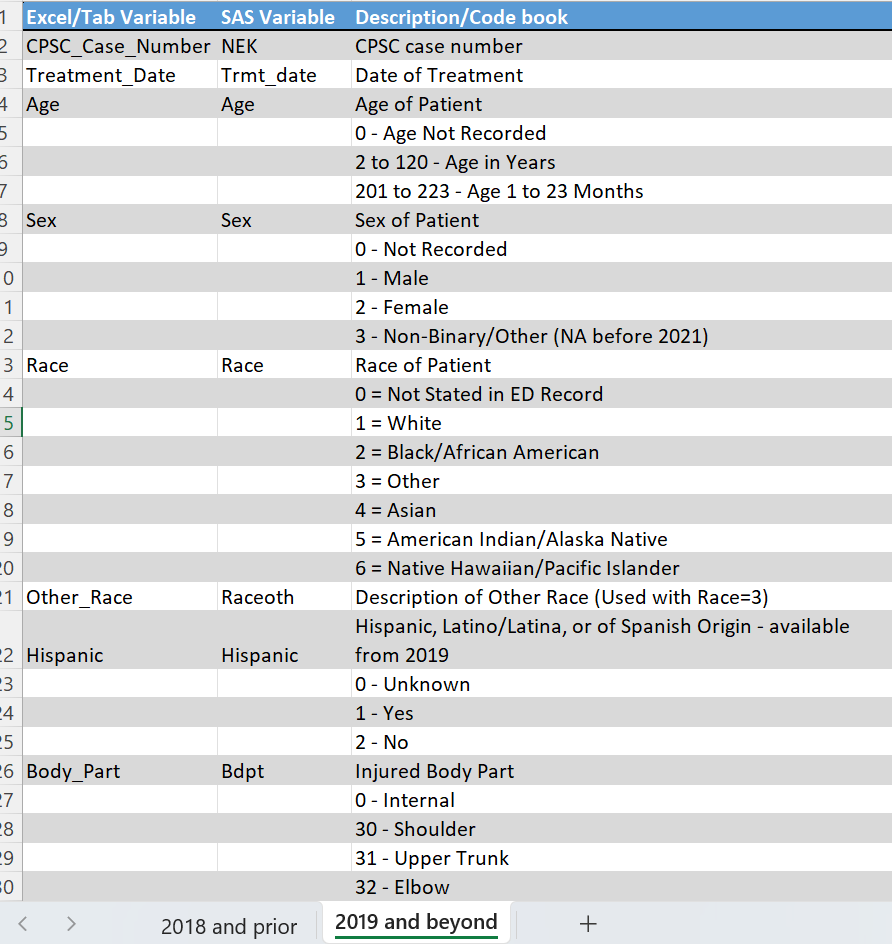

```python
# Loading the data disctionary for the neiss raw dataset
neiss_dictionary = (
    pd.read_excel("D:/Personal/Projects/diagnosis/DataDictionary042022.xlsx", sheet_name='2019 and beyond')#"sheet_name=1" works as well due to indexing
    .clean_names()
)

# Previewing the rows
neiss_dictionary.head()
```

|  | excel_tab_variable | sas_variable | description_code_book |
| --- | --- | --- | --- |
| 0 | CPSC_Case_Number | NEK | CPSC case number |
| 1 | Treatment_Date | Trmt_date | Date of Treatment |
| 2 | Age | Age | Age of Patient |
| 3 | NaN | NaN | 0 - Age Not Recorded |
| 4 | NaN | NaN | 2 to 120 - Age in Years |

#### 3. NEISS-Formats: This dataset contains the mapping for the codes found in NEISS-2024, allowing us to translate an integer like 5040 into a human-readable significant figure.

```python
neiss_format = (
    pd.read_excel("D:/Personal/Projects/diagnosis/NEISS-formats.xlsx")
    .clean_names()
)

neiss_format.head(10)
```

|  | format_name | format | label |
| --- | --- | --- | --- |
| 0 | BDYPT | 0 | INTERNAL |
| 1 | BDYPT | 30 | SHOULDER |
| 2 | BDYPT | 31 | UPPER TRUNK |
| 3 | BDYPT | 32 | ELBOW |
| 4 | BDYPT | 33 | LOWER ARM |
| 5 | BDYPT | 34 | WRIST |
| 6 | BDYPT | 35 | KNEE |
| 7 | BDYPT | 36 | LOWER LEG |
| 8 | BDYPT | 37 | ANKLE |
| 9 | BDYPT | 38 | PUBIC REGION |

# Data Inspection

### .info()

Before we apply our "Tidy" Python methods, we must perform an initial scan to understand the dimensions and data types. Using neiss_2024.info(), we can see the structure of our data:

```python
neiss_2024.info()
```

```
<class 'pandas.core.frame.DataFrame'>
RangeIndex: 361672 entries, 0 to 361671
Data columns (total 25 columns):
 #   Column             Non-Null Count   Dtype
---  ------             --------------   -----
 0   cpsc_case_number   361672 non-null  int64
 1   treatment_date     361672 non-null  datetime64[ns]
 2   age                361672 non-null  int64
 3   sex                361672 non-null  int64
 4   race               361672 non-null  int64
 5   other_race         15277 non-null   object
 6   hispanic           361672 non-null  int64
 7   body_part          361672 non-null  int64
 8   diagnosis          361672 non-null  int64
 9   other_diagnosis    77535 non-null   object
```

[output cut: 17 more lines]

**Insights from .info():**

1. Range: 361,672 entries.
2. Composition: 25 columns consisting of integers (codes), objects (narratives), and timestamps.
3. Blanks: other_diagnosis, other_diagnosis_2, body_part_2, diagnosis_2 have blanks
4. Columns like sex, race, body_part, and product_1 are currently stored as int64. These are just numbers. Our task is to use .assign() and .merge() to breathe descriptive life into these columns.

### .describe()

After understanding the structure, we use neiss_2024.describe() to perform a statistical scan of our 361,672 cases.

```python
# Checking the descriptive statisics of the numerical columns
neiss_2024.describe()
```

|  | cpsc_case_number | treatment_date | age | sex | race | hispanic | body_part | diagnosis | body_part_2 | diagnosis_2 | disposition | location | fire_involvement | product_1 | product_2 | product_3 | alcohol | drug | psu | weight |
| --- | --- | --- | --- | --- | --- | --- | --- | --- | --- | --- | --- | --- | --- | --- | --- | --- | --- | --- | --- | --- |
| count | 3.616720e+05 | 361672 | 361672.000000 | 361672.000000 | 361672.000000 | 361672.000000 | 361672.000000 | 361672.000000 | 88551.000000 | 88551.000000 | 361672.000000 | 361672.000000 | 361672.000000 | 361672.000000 | 361672.000000 | 361672.000000 | 361672.000000 | 361672.000000 | 361672.000000 | 361672.000000 |
| mean | 2.412749e+08 | 2024-07-05 15:46:33.346457088 | 47.561575 | 1.450859 | 1.210887 | 1.575179 | 64.598329 | 61.202866 | 65.320821 | 61.394146 | 1.472812 | 2.432837 | 0.011248 | 2189.587192 | 312.119113 | 31.325386 | 0.018215 | 0.027464 | 53.668205 | 41.664765 |
| min | 2.401085e+08 | 2024-01-01 00:00:00 | 0.000000 | 0.000000 | 0.000000 | 0.000000 | 0.000000 | 41.000000 | 0.000000 | 41.000000 | 1.000000 | 0.000000 | 0.000000 | 106.000000 | 0.000000 | 0.000000 | 0.000000 | 0.000000 | 2.000000 | 6.580100 |
| 25% | 2.405001e+08 | 2024-04-12 00:00:00 | 13.000000 | 1.000000 | 1.000000 | 1.000000 | 36.000000 | 57.000000 | 35.000000 | 53.000000 | 1.000000 | 0.000000 | 0.000000 | 1211.000000 | 0.000000 | 0.000000 | 0.000000 | 0.000000 | 21.000000 | 27.587000 |
| 50% | 2.407884e+08 | 2024-07-08 00:00:00 | 34.000000 | 1.000000 | 1.000000 | 2.000000 | 75.000000 | 59.000000 | 76.000000 | 59.000000 | 1.000000 | 1.000000 | 0.000000 | 1807.000000 | 0.000000 | 0.000000 | 0.000000 | 0.000000 | 41.000000 | 27.587000 |
| 75% | 2.410680e+08 | 2024-09-30 00:00:00 | 67.000000 | 2.000000 | 2.000000 | 2.000000 | 82.000000 | 65.000000 | 82.000000 | 71.000000 | 1.000000 | 5.000000 | 0.000000 | 3285.000000 | 0.000000 | 0.000000 | 0.000000 | 0.000000 | 73.000000 | 53.129500 |
| max | 2.503063e+08 | 2024-12-31 00:00:00 | 223.000000 | 2.000000 | 6.000000 | 2.000000 | 94.000000 | 74.000000 | 94.000000 | 74.000000 | 9.000000 | 9.000000 | 3.000000 | 5555.000000 | 5555.000000 | 5555.000000 | 1.000000 | 1.000000 | 207.000000 | 108.065600 |
| std | 2.194381e+06 | NaN | 50.063627 | 0.499554 | 0.900027 | 0.725550 | 24.003102 | 6.746135 | 22.776818 | 7.328551 | 1.200245 | 3.288587 | 0.169658 | 1392.884748 | 839.127837 | 274.427963 | 0.133730 | 0.163432 | 44.858434 | 29.854678 |

### .duplicated()

Using .duplicated(), we can check for duplicates

```python
neiss_2024[neiss_2024.duplicated(keep='first')]
```

|  | cpsc_case_number | treatment_date | age | sex | race | other_race | hispanic | body_part | diagnosis | other_diagnosis | ... | fire_involvement | product_1 | product_2 | product_3 | alcohol | drug | narrative_1 | stratum | psu | weight |
| --- | --- | --- | --- | --- | --- | --- | --- | --- | --- | --- | --- | --- | --- | --- | --- | --- | --- | --- | --- | --- | --- |

0 rows × 25 columns

**Logic of .duplicated() :**

# Data Wrangling

## Step 1: Normalizing the Biological Clock

In data wrangling, accuracy often hinges on how we handle outliers or specialized encoding. In the NEISS dataset, age is a perfect example of a variable that requires attention.

For most patients, age is recorded in years. However, according to the neiss_disctionary, for infants the system uses a specialized 200-series code. In this system, 201 represents a 1-month-old, while 223 represents a 23-month-old. If we were to calculate a mean age without addressing this, a 1-month-old infant would appear to be a 201-year-old giant!

```python
neiss_dictionary[2:6]
```

|  | excel_tab_variable | sas_variable | description_code_book |
| --- | --- | --- | --- |
| 2 | Age | Age | Age of Patient |
| 3 | NaN | NaN | 0 - Age Not Recorded |
| 4 | NaN | NaN | 2 to 120 - Age in Years |
| 5 | NaN | NaN | 201 to 223 - Age 1 to 23 Months |

The task is to align the ages as per the above neiss_dictionary.

Using Python’s .assign() can normalize this biological clock in a single, readable chain.

```python
neiss_coded = (
    neiss_2024 # Directing our functions to the raw data
    .assign(
        correct_age = lambda x: np.where(
            # First, we identify '0' as missing/not recorded to prevent it from skewing our year-based averages.
            x['age'] == 0, np.nan,
            np.where(
                # Next, we handle the 'month codes' (201-223) by subtracting 200 to get months, then divide by 12
                #to convert them into year-based significant figures.
                x['age'].between(201, 223), np.trunc(((x['age'] - 200) / 12)).astype('int'),
                x['age']
            )
        )
    )
)
```

In data wrangling, you never take a transformation at face value. After normalizing the ages with .assign(), we must perform an audit. It's imperative to ensure that the significant figures set to np.nan (Not a Number) are the exact same cases in the raw data (neiss_2024), which the Data Dictionary identified as "Not Recorded" (Age = 0)

```python
# Counting the totals np.nan
neiss_coded['correct_age'].isna().sum()
```

```
np.int64(29)
```

```python
# The Precision Audit: Do the Case Numbers match exactly?
audit_check = (
    neiss_coded[neiss_coded['correct_age'].isna()]['cpsc_case_number']
    .isin(neiss_2024[neiss_2024['age'] == 0]['cpsc_case_number'])
    .all()
)
print(f"Audit Result: {audit_check}")
```

```
Audit Result: True
```

## Step 2: Renaming and Selecting (The select logic)

Next, I need to bond the raw product codes (like 5040) to their actual names (like Bicycles). In R, I would use a join and then a select(new _name = old_name). In Python, I use a .merge() followed by a rename within the chain.

```python
neiss_format.head()
```

|  | format_name | format | label |
| --- | --- | --- | --- |
| 0 | BDYPT | 0 | INTERNAL |
| 1 | BDYPT | 30 | SHOULDER |
| 2 | BDYPT | 31 | UPPER TRUNK |
| 3 | BDYPT | 32 | ELBOW |
| 4 | BDYPT | 33 | LOWER ARM |

```python
neiss_coded[['body_part']].head()
```

|  | body_part |
| --- | --- |
| 0 | 30 |
| 1 | 92 |
| 2 | 93 |
| 3 | 0 |
| 4 | 76 |

```python
neiss_coded = (
    neiss_coded
    .merge(
        # Filtering for 'BDYPT' codes and selecting our 'Key' and 'Value'
        neiss_format[neiss_format['format_name'] == 'BDYPT'][['format', 'label']]
        # Rename columns for easier merging by exisitin column in neiss_coded
        .rename(columns = {
            'label' : 'body_part_text_1',
            'format' : 'body_part'
        }),
        on = 'body_part',
        how = 'left'
    )
    .merge(
        neiss_format[neiss_format['format_name'] == 'BDYPT'][['format', 'label']]
        .rename(columns = {
            'label' : 'body_part_text_2',
            'format' : 'body_part_2'
        }),
        on = 'body_part_2',
        how = 'left'
    )

)
```

To ensure our bond was successful, we use the .filter() method with a Regular Expression (Regex).

I want to see every column that starts with the word "body" to confirm that our numerical codes now sit side-by-side with their human-readable labels.

```python
# The Targeted Scan
neiss_coded.filter(regex='^body')
```

|  | body_part | body_part_2 | body_part_text_1 | body_part_text_2 |
| --- | --- | --- | --- | --- |
| 0 | 30 | NaN | SHOULDER | NaN |
| 1 | 92 | NaN | FINGER | NaN |
| 2 | 93 | NaN | TOE | NaN |
| 3 | 0 | NaN | INTERNAL | NaN |
| 4 | 76 | NaN | FACE | NaN |
| ... | ... | ... | ... | ... |
| 361667 | 85 | NaN | ALL PARTS BODY | NaN |
| 361668 | 36 | 37.0 | LOWER LEG | ANKLE |
| 361669 | 36 | NaN | LOWER LEG | NaN |
| 361670 | 87 | NaN | NOT STATED/UNK | NaN |
| 361671 | 35 | NaN | KNEE | NaN |

361672 rows × 4 columns

Now we proceed to the next items in the ness_format.

```python
neiss_format.value_counts('format_name')
```

```
format_name
PROD           1114
DIAG             31
BDYPT            30
LOCATION         10
RACE              7
DISPOSITION       7
FIRE_DEPART       4
GENDER            3
Name: count, dtype: int64
```

```python
neiss_coded.columns
```

```
Index(['cpsc_case_number', 'treatment_date', 'age', 'sex', 'race',
       'other_race', 'hispanic', 'body_part', 'diagnosis', 'other_diagnosis',
       'body_part_2', 'diagnosis_2', 'other_diagnosis_2', 'disposition',
       'location', 'fire_involvement', 'product_1', 'product_2', 'product_3',
       'alcohol', 'drug', 'narrative_1', 'stratum', 'psu', 'weight',
       'correct_age', 'body_part_text_1', 'body_part_text_2'],
      dtype='object')
```

```python
neiss_coded = (
    neiss_coded
    .merge(
        neiss_format[neiss_format['format_name'] == 'PROD'][['format', 'label']]
        .rename(columns = {
            'label' : 'product_text_1',
            'format' : 'product_1'
        }),
        on = 'product_1',
        how = 'left'
    )
    .merge(
        neiss_format[neiss_format['format_name'] == 'PROD'][['format', 'label']]
        .rename(columns = {
            'label' : 'product_text_2',
            'format' : 'product_2'
        }),
        on = 'product_2',
        how = 'left'
    )
    .merge(
        neiss_format[neiss_format['format_name'] == 'PROD'][['format', 'label']]
        .rename(columns = {
            'label' : 'product_text_3',
            'format' : 'product_3'
        }),
        on = 'product_3',
        how = 'left'
    )
    .merge(
        neiss_format[neiss_format['format_name'] == 'DIAG'][['format', 'label']]
        .rename(columns = {
            'label' : 'diagnosis_text_1',
            'format' : 'diagnosis'
        }),
        on = 'diagnosis',
        how = 'left'
    )
    .merge(
        neiss_format[neiss_format['format_name'] == 'DIAG'][['format', 'label']]
        .rename(columns = {
            'label' : 'diagnosis_text_2',
            'format' : 'diagnosis_2'
        }),
        on = 'diagnosis_2',
        how = 'left'
    )
    .merge(
        neiss_format[neiss_format['format_name'] == 'LOCATION'][['format', 'label']]
        .rename(columns = {
            'label' : 'location_text',
            'format' : 'location'
        }),
        on = 'location',
        how = 'left'
    )
    .merge(
        neiss_format[neiss_format['format_name'] == 'RACE'][['format', 'label']]
        .rename(columns = {
            'label' : 'race_text',
            'format' : 'race'
        }),
        on = 'race',
        how = 'left'
    )
    .merge(
        neiss_format[neiss_format['format_name'] == 'DISPOSITION'][['format', 'label']]
        .rename(columns = {
            'label' : 'disposition_text',
            'format' : 'disposition'
        }),
        on = 'disposition',
        how = 'left'
    )
    .merge(
        neiss_format[neiss_format['format_name'] == 'FIRE_DEPART'][['format', 'label']]
        .rename(columns = {
            'label' : 'fire_involvement_text',
            'format' : 'fire_involvement'
        }),
        on = 'fire_involvement',
        how = 'left'
    )
    .merge(
        neiss_format[neiss_format['format_name'] == 'GENDER'][['format', 'label']]
        .rename(columns = {
            'label' : 'sex_text',
            'format' : 'sex'
        }),
        on = 'sex',
        how = 'left'
    )
    .assign(
        hispanic_text = lambda x: np.where(
            x['hispanic'] == 0, 'Unknown',
            np.where(
                x['hispanic'] == 1, 'Yes',
                'No'
            )
        )
    )
    .assign(
        age_group_text = lambda x: np.select(
            condlist=[
                x['age'] <= 5,
                x['age'] <= 12,
                x['age'] <= 19,
                x['age'] <= 35,
                x['age'] <= 64
            ],
            choicelist=[
                'Infant',
                'Child',
                'Teen',
                'Youth',
                'Adult'
            ], default='Elderly (65+)'
        )
    )
    .assign(
        alcohol_text = lambda x: np.where(
            x['alcohol'] == 1, 'Yes',
            'No/No Information'
        )
    )
    .assign(
        drug_text = lambda x: np.where(
            x['drug'] == 1, 'Yes',  'No/No Information'
        )
    )

)
```

```python
# Targeting columns that contain "text" to verify output
neiss_coded.filter(regex = "text").head()
```

|  | body_part_text_1 | body_part_text_2 | product_text_1 | product_text_2 | product_text_3 | diagnosis_text_1 | diagnosis_text_2 | location_text | race_text | disposition_text | fire_involvement_text | sex_text | hispanic_text | age_group_text | alcohol_text | drug_text |
| --- | --- | --- | --- | --- | --- | --- | --- | --- | --- | --- | --- | --- | --- | --- | --- | --- |
| 0 | SHOULDER | NaN | SOCCER (ACTIVITY, APPAREL OR EQUIP.) | NaN | NaN | STRAIN, SPRAIN | NaN | SPORTS | N.S. | 1=TREATED & RELEASED, OR EXAMINED & RELEASED WITHOUT TRTMNT | NO FIRE OR NO FLAME/SMOKE SPREAD | MALE | Yes | Teen | No/No Information | No/No Information |
| 1 | FINGER | NaN | KNIVES, NOT ELSEWHERE CLASSIFIED | NaN | NaN | LACERATION | NaN | HOME | WHITE | 1=TREATED & RELEASED, OR EXAMINED & RELEASED WITHOUT TRTMNT | NO FIRE OR NO FLAME/SMOKE SPREAD | FEMALE | No | Adult | No/No Information | No/No Information |
| 2 | TOE | NaN | TWO-WHEELED, POWERED, OFF-ROAD VEHICLES | FOOTWEAR | NaN | CRUSHING | NaN | UNK | WHITE | 1=TREATED & RELEASED, OR EXAMINED & RELEASED WITHOUT TRTMNT | NO FIRE OR NO FLAME/SMOKE SPREAD | MALE | No | Child | No/No Information | No/No Information |
| 3 | INTERNAL | NaN | COINS | NaN | NaN | INGESTION | NaN | UNK | N.S. | 2=TREATED & TRANSFERRED | NO FIRE OR NO FLAME/SMOKE SPREAD | FEMALE | No | Infant | No/No Information | No/No Information |
| 4 | FACE | NaN | CHAIRS, OTHER OR NOT SPECIFIED | NaN | NaN | LACERATION | NaN | UNK | N.S. | 1=TREATED & RELEASED, OR EXAMINED & RELEASED WITHOUT TRTMNT | NO FIRE OR NO FLAME/SMOKE SPREAD | MALE | Yes | Infant | No/No Information | No/No Information |

In every data wrangling/cleanning, there comes a point where one must decide which evidence is actionable and which is incomplete. Initially, our audit confirmed that 29 cases had no recorded age. While we could keep these rows as "Not recorded," for our age-based risk analysis, they act as background noise.

To ensure the insights we draw from the data are as precise as a clinical report, we use .dropna(). This is our version of filtering for quality.

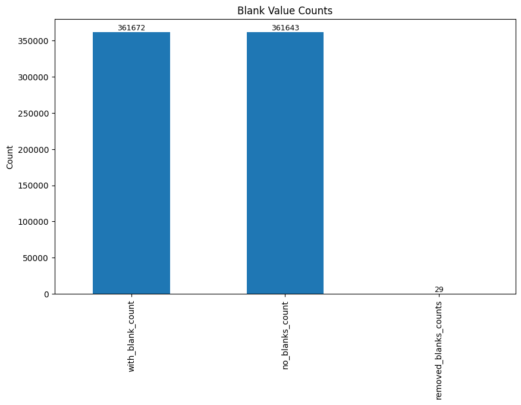

```python
# Purging the 29 'Not Recorded' cases to finalize the registry
neiss_clean = neiss_coded.dropna(subset = ['correct_age'])

# Verifying the "Mass Balance"
df_counts = pd.DataFrame ({
    'count' : [
        len(neiss_coded['correct_age']),
        len(neiss_clean['correct_age']),
        len(neiss_coded['correct_age']) - len(neiss_clean['correct_age'])
              ]
    }, index = ['with_blank_count', 'no_blanks_count', 'removed_blanks_counts']).reset_index()

ax = (
    df_counts
    .plot(
        kind='bar',
        x='index',
        y='count',
        legend=False,
        figsize=(10, 6)
    )
)

ax.set_title('Blank Value Counts')
ax.set_xlabel('')
ax.set_ylabel('Count')

# Add value labels on top of bars
for i, v in enumerate(df_counts['count']):
    ax.text(
        i,
        v,
        f"{v}",
        ha='center',
        va='bottom',
        fontsize=9
    )
```

# Exploratory Data Analysis (EDA)

In my R days, this was the moment I would reach for count(), group_by(), and adorn_totals() to see the patterns hidden in the data. In Python, we use the "Tidy" equivalents: .value_counts(), .groupby(), and the powerful .pivot_table().

To maximize impact and move beyond simple reporting, we focus on the following explorations:

### 1. Frequency: "What is hurting most?"

The first insight comes from identifying the most common products involved in ER visits. By using .value_counts(), we can generate a ranking of the most active hazards in the dataset.

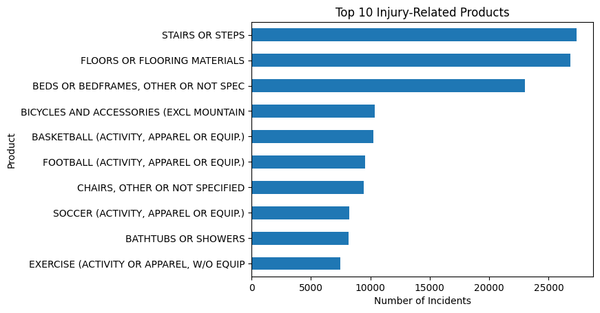

```python
top_hazards = (
    neiss_clean['product_text_1']
    .value_counts()
    .head(10)
    .reset_index(name = 'incident_count')
    .rename(columns = {'product_text_1':'product'})
)


ax = (
    top_hazards.sort_values('incident_count')
    .plot(
        kind = 'barh',
        x = 'product',
        y = 'incident_count',
        legend = False
    )
)

ax.set_title('Top 10 Injury-Related Products')
ax.set_xlabel('Number of Incidents')
ax.set_ylabel('Product')
```

High-frequency products represent exposure-driven risk and are prime candidates for prevention messaging, safety standards, or product redesign.

It appears stairs/step, floors or floring materials and bed/bed frames seem to be most common.

### 2. Severity: "What causes the most harm?"

To measure this, we look at the disposition column. In the NEISS world, "Disposition" tracks what happened to the patient after the ER visit.

```python
neiss_clean['disposition_text'].value_counts()
```

```
disposition_text
1=TREATED & RELEASED, OR EXAMINED & RELEASED WITHOUT TRTMNT    308438
4=TREATED & ADMITTED FOR HOSPITALIZATION, HOSPITALIZED          38133
6=LEFT WITHOUT BEING SEEN                                        7664
2=TREATED & TRANSFERRED                                          4106
5=HELD FOR OBSERVATION                                           3008
8=FATALITIES, INCLUDING DOA, DIED IN ER, EXPIRED IN HOSP.         291
9=UNKNOWN, NOT STATED, ETC.                                         3
Name: count, dtype: int64
```

By focusing on Dispositions 4 (Hospitalized) and 8 (Fatalities), we can identify which products are the most dangerous.

```python
# Calculating the Severity Index (Hospitalization Rate)
severity_index = (
    neiss_clean
    .loc[neiss_clean['disposition'].isin([4, 8])]
    .groupby(['product_text_1', 'disposition_text'])['cpsc_case_number']
    .count()
    .reset_index()
    .rename(columns={'cpsc_case_number' : 'incident_count'})
    .sort_values(by = 'incident_count', ascending=False)
)

display(severity_index.head(15))
```

|  | product_text_1 | disposition_text | incident_count |
| --- | --- | --- | --- |
| 227 | FLOORS OR FLOORING MATERIALS | 4=TREATED & ADMITTED FOR HOSPITALIZATION, HOSPITALIZED | 7082 |
| 66 | BEDS OR BEDFRAMES, OTHER OR NOT SPEC | 4=TREATED & ADMITTED FOR HOSPITALIZATION, HOSPITALIZED | 4348 |
| 516 | STAIRS OR STEPS | 4=TREATED & ADMITTED FOR HOSPITALIZATION, HOSPITALIZED | 3468 |
| 110 | CHAIRS, OTHER OR NOT SPECIFIED | 4=TREATED & ADMITTED FOR HOSPITALIZATION, HOSPITALIZED | 1490 |
| 58 | BATHTUBS OR SHOWERS | 4=TREATED & ADMITTED FOR HOSPITALIZATION, HOSPITALIZED | 1349 |
| 555 | TOILETS | 4=TREATED & ADMITTED FOR HOSPITALIZATION, HOSPITALIZED | 1224 |
| 71 | BICYCLES AND ACCESSORIES (EXCL MOUNTAIN | 4=TREATED & ADMITTED FOR HOSPITALIZATION, HOSPITALIZED | 1112 |
| 200 | EXERCISE (ACTIVITY OR APPAREL, W/O EQUIP | 4=TREATED & ADMITTED FOR HOSPITALIZATION, HOSPITALIZED | 704 |
| 316 | LADDERS, OTHER OR NOT SPECIFIED | 4=TREATED & ADMITTED FOR HOSPITALIZATION, HOSPITALIZED | 675 |
| 106 | CEILINGS AND WALLS (PART OF COMPLETED ST | 4=TREATED & ADMITTED FOR HOSPITALIZATION, HOSPITALIZED | 641 |
| 508 | SOFAS, COUCHES, DAVENPORTS, DIVANS OR ST | 4=TREATED & ADMITTED FOR HOSPITALIZATION, HOSPITALIZED | 594 |
| 536 | TABLES, NOT ELSEWHERE CLASSIFIED | 4=TREATED & ADMITTED FOR HOSPITALIZATION, HOSPITALIZED | 503 |
| 235 | FOOTWEAR | 4=TREATED & ADMITTED FOR HOSPITALIZATION, HOSPITALIZED | 433 |
| 473 | RUGS OR CARPETS, NOT SPECIFIED | 4=TREATED & ADMITTED FOR HOSPITALIZATION, HOSPITALIZED | 423 |
| 170 | DOORS, OTHER OR NOT SPECIFIED | 4=TREATED & ADMITTED FOR HOSPITALIZATION, HOSPITALIZED | 337 |

Frequency tells us what happens most often, but Severity tells us which incidents are life-altering.

When we look at the top 15 results, the data tells a sobering story. The products causing the most hospitalizations are common things in our lives:

1. Floors or Flooring Materials (7,082 cases): Far and away the leading cause of serious hospitalizations.
2. Beds or Bedframes (4,348 cases): A reminder of the risks associated with falls, particularly for the elderly.
3. Stairs or Steps (3,468 cases): The classic vertical hazard.

#### The Narrative Deep-Dive: The Story Behind the Fall

```python
# Investigating the 'Floor' narratives for those hospitalized
floor_stories = (
    neiss_clean
    .loc[(neiss_clean['product_text_1'].str.contains('FLOOR')) &
         (neiss_clean['disposition'] == 4)]
    ['narrative_1']
)


floor_stories.head(10).reset_index()
```

|  | index | narrative_1 |
| --- | --- | --- |
| 0 | 28 | 92YOF HAD A SLIP AND FALL TO FLOOR AT THE NURSING HOME STRIKING HEAD DX:HEMATOMA TO SCALP ADMITTED FOR PULMONARY EDEMA |
| 1 | 33 | 92YOM FELL TO FLOOR AT NURSING HOME LANDING ON RIGHT HIP DX:RIGHT HIP INJURY ADMITTED FOR AMBULATORY DISFUNCTION |
| 2 | 50 | 95YOM FROM NURSING HOME HAD A TRIP AND FALL HITTING HEAD ON FLOOR DX:SUBDURAL HEMATOMA |
| 3 | 100 | 76YOF HAD A FALL TO THE FLOOR AT THE NURSING HOME ONTO HEAD DX SUBDURAL HEMATOMA |
| 4 | 121 | 86YOF, NH PT FELL TO FLOOR, C/O HEMATOMA RIGHT SIDE HEAD, BRUISING, SWELLING OF LIP DX: SYNCOPE, RIGHT ORBITAL FLOOR FRACTURE, HYPOKALEMIA, HYPONATREMIA |
| 5 | 129 | 77YOF, LET GO OF WALKER, LEGS GAVE OUT, SAT IN FLOOR, COULDNT GET UP SLID ON FLOOR X 24 HOURS, UNABLE TO WALK, DIZZINESS DX: COVID, NONAMBULATORY, GENRAL WEAKNESS |
| 6 | 298 | 77YOF PATIENT FELL DOWN ON THE FLOOR ONTO THE LEFT SIDE OF HER HEAD DX: TRAUMATIC INJURY OF HEAD, HYPONATREMIA, HYPOCALCEMIA |
| 7 | 314 | 81YOF WITH FALL AT HOME, POSS. DUE TO POLYLPHARMACY. PATIENT FELL IN THE FLOOR. DX: STABLE BURST FRACTURE THORACIC SPINE. POLYPHARMACY |
| 8 | 509 | 30YOM HAD A FALL ONTO THE FLOOR FROM A CHAIR DX FRACTURED COCCYX |
| 9 | 563 | 70YOM HAD A SLIP AND FALL IN THE BATHROOM WHILE INTOXICATED LANDING ON THE FLOOR NO BAC OBTAINED DX FRACTURED LEFT HIP ACUTE ALCOHOL INTOXICATION |

The severity isn't just about "Floors", but specifically about geriatric falls in care facilities. There's recurring mentions of nursing homes, walkers giving out, and polypharmacy (medication interactions) leading to loss of balance.

Without this narrative scan, we might have suggested that slippery floors were the problem. But the text reveals the true mechanism: frailty and mobility failure in high-density care environments.

To isolate the most tragic outcomes, we filter our registry for Disposition 8 (Fatalities).

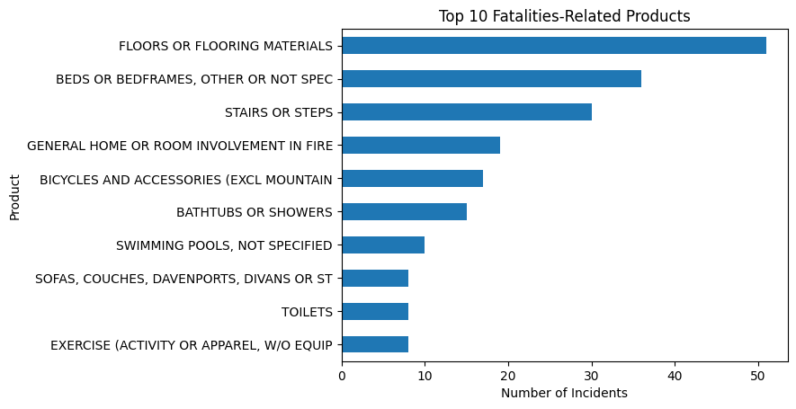

```python
# Isolating the most critical outcomes
fatality_index = (
    neiss_clean
    .loc[neiss_clean['disposition'] == 8]
    .value_counts('product_text_1')
    .reset_index(name = 'incident_count')
)

ax = (
    fatality_index.head(10).sort_values('incident_count')
    .plot(
    kind = 'barh',
    legend = False,
    x = 'product_text_1',
    y = 'incident_count'
    )
)

ax.set_title('Top 10 Fatalities-Related Products')
ax.set_xlabel('Number of Incidents')
ax.set_ylabel('Product')
```

### Which diagnoses lead to hospitalization?

If Frequency is the volume of the signal and Severity is the intensity, then Diagnosis is the identity of the trauma. By looking at what specifically is happening to these patients (biologically), we can confirm our "Nursing Home" and "Floor Fall" hypotheses.

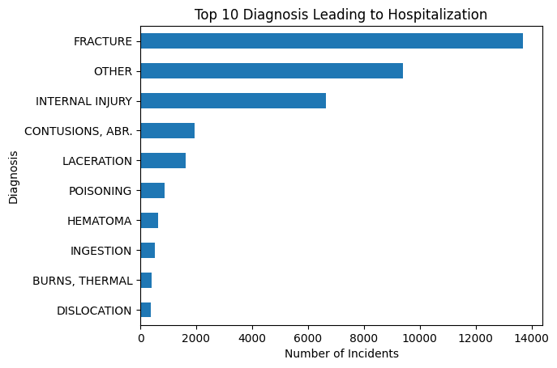

```python
hospitalization = (
    neiss_clean[neiss_clean['disposition'] == 4]
    .value_counts('diagnosis_text_1')
    .reset_index(name = 'incident_count')
)

ax = (
    hospitalization.head(10).sort_values('incident_count')
    .plot(
    kind = 'barh',
    legend = False,
    x = 'diagnosis_text_1',
    y = 'incident_count'
    )
)

ax.set_title('Top 10 Diagnosis Leading to Hospitalization')
ax.set_xlabel('Number of Incidents')
ax.set_ylabel('Diagnosis')
```

Fractures are the overwhelming leader in hospitalizations.

We now see that Fractures (likely hip and femur based on the narrative "fell to floor") are the medical bridge between the product (Floor) and the outcome (Hospitalization).

This provides us with a Causal Map:

1. The Victim: Elderly patients in care.
2. The Hazard: Interior floors/beds.
3. The Event: A slip or trip.
4. The Clinical Result: A high-severity fracture requiring admission.

### Which diagnoses lead to fatalities?

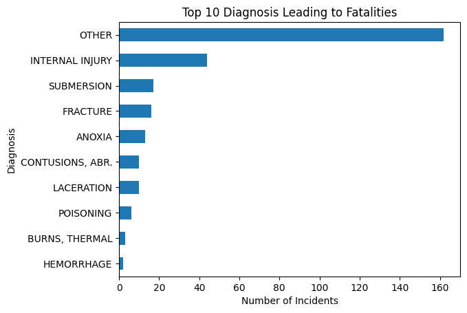

```python
fatalities = (
    neiss_clean[neiss_clean['disposition'] == 8]
    .value_counts('diagnosis_text_1')
    .reset_index(name = 'incident_count')
)

ax = (
    fatalities.head(10).sort_values('incident_count')
    .plot(
    kind = 'barh',
    legend = False,
    x = 'diagnosis_text_1',
    y = 'incident_count'
    )
)

ax.set_title('Top 10 Diagnosis Leading to Fatalities')
ax.set_xlabel('Number of Incidents')
ax.set_ylabel('Diagnosis')
```

#### Which injuries affect critical body parts?

```python
# Slicing for Critical Outcomes only
critical_injuries = (
    neiss_clean
    .loc[neiss_clean['disposition'].isin([4, 8])]
    .groupby(['body_part_text_1', 'product_text_1'])['cpsc_case_number']
    .count()
    .reset_index(name='incident_count')
    .sort_values('incident_count', ascending=False)
)

# Viewing the Top 5 most dangerous product-body part combinations
display(critical_injuries.head(15))
```

|  | body_part_text_1 | product_text_1 | incident_count |
| --- | --- | --- | --- |
| 1272 | HEAD | FLOORS OR FLOORING MATERIALS | 1928 |
| 2161 | LOWER TRUNK | FLOORS OR FLOORING MATERIALS | 1428 |
| 2614 | NOT STATED/UNK | FLOORS OR FLOORING MATERIALS | 1015 |
| 1197 | HEAD | BEDS OR BEDFRAMES, OTHER OR NOT SPEC | 967 |
| 2083 | LOWER TRUNK | BEDS OR BEDFRAMES, OTHER OR NOT SPEC | 904 |
| 1400 | HEAD | STAIRS OR STEPS | 847 |
| 2576 | NOT STATED/UNK | BEDS OR BEDFRAMES, OTHER OR NOT SPEC | 783 |
| 2303 | LOWER TRUNK | STAIRS OR STEPS | 608 |
| 3499 | UPPER TRUNK | STAIRS OR STEPS | 512 |
| 3362 | UPPER TRUNK | FLOORS OR FLOORING MATERIALS | 492 |
| 648 | FACE | FLOORS OR FLOORING MATERIALS | 441 |
| 3299 | UPPER TRUNK | BEDS OR BEDFRAMES, OTHER OR NOT SPEC | 373 |
| 96 | ALL PARTS BODY | FLOORS OR FLOORING MATERIALS | 373 |
| 1192 | HEAD | BATHTUBS OR SHOWERS | 357 |
| 2106 | LOWER TRUNK | CHAIRS, OTHER OR NOT SPECIFIED | 350 |

When we look at this output, we see that Floors and Beds aren't just causing injuries—they are systematically damaging the most vital areas of the human body: the Head, Lower Trunk (hips/pelvis), and Upper Trunk (chest/spine).

#### Insights:

1. The Head (Traumatic Brain Injury Risk): Floors (1,928) and Beds (967) are the primary culprits for severe head trauma. This aligns with our nursing home narratives—elderly patients falling from a standing height or rolling out of bed directly onto a hard surface.
2. The Lower Trunk (The Hip Fracture Signal): With 1,428 floor-related injuries and 904 bed-related injuries to the lower trunk, we are seeing the statistical fingerprint of the "broken hip" crisis in the aging population.

### 3. Demographics: "Who is most affected?"

Key breakdowns

1. Age groups (children, teens, adults, elderly)

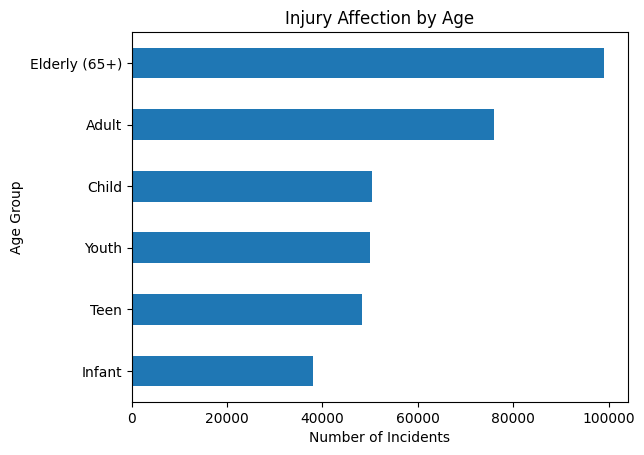

```python
# Categorizing Age Group affection

age_group = (
    neiss_clean
    .value_counts('age_group_text')
    .reset_index(name = 'incident_count')
)

ax = (
    age_group.head(10).sort_values('incident_count')
    .plot(
    kind = 'barh',
    legend = False,
    x = 'age_group_text',
    y = 'incident_count'
    )
)

ax.set_title('Injury Affection by Age')
ax.set_xlabel('Number of Incidents')
ax.set_ylabel('Age Group')
```

2. Sex-based injury differences

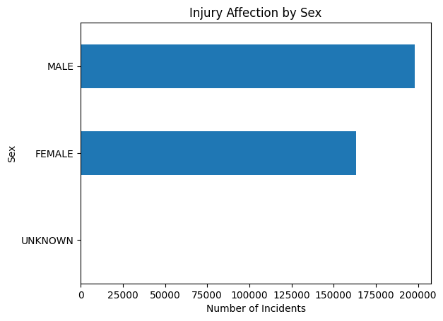

```python
# Categorizing sex injury affection
sex = (
    neiss_clean
    .value_counts('sex_text')
    .reset_index(name = 'incident_count')
)

ax = (
    sex.head(10).sort_values('incident_count')
    .plot(
    kind = 'barh',
    legend = False,
    x = 'sex_text',
    y = 'incident_count'
    )
)

ax.set_title('Injury Affection by Sex')
ax.set_xlabel('Number of Incidents')
ax.set_ylabel('Sex')
```

3. Racial / ethnic disparities (careful, descriptive framing)

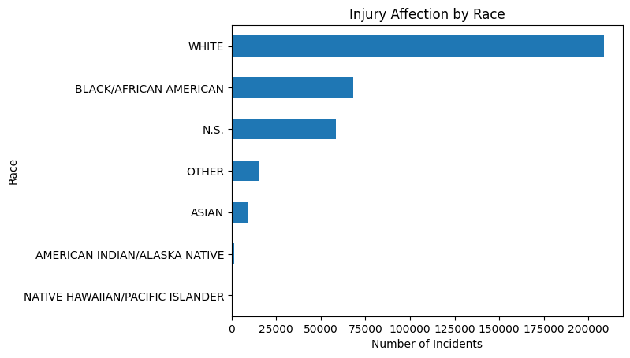

```python
# Categorizing race injury affection
race = (
    neiss_clean
    .value_counts('race_text')
    .reset_index(name = 'incident_count')
)

ax = (
    race.head(10).sort_values('incident_count')
    .plot(
    kind = 'barh',
    legend = False,
    x = 'race_text',
    y = 'incident_count'
    )
)

ax.set_title('Injury Affection by Race')
ax.set_xlabel('Number of Incidents')
ax.set_ylabel('Race')
```

### 4. Time Patterns: "When do injuries happen?"

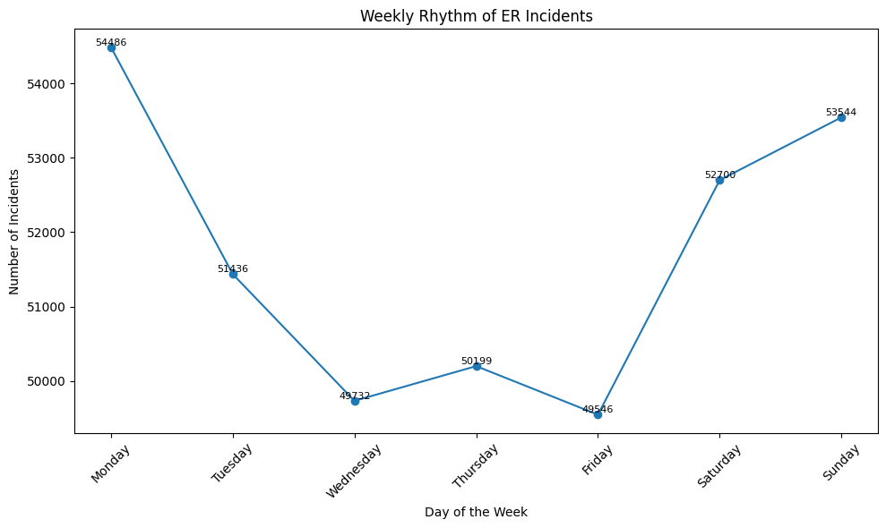

```python
# Create a truly independent object
neiss_clean = neiss_coded.dropna(subset=['correct_age']).copy()

# Now this will run without warnings
neiss_clean['day_of_week'] = pd.to_datetime(neiss_clean['treatment_date']).dt.day_name()

# Comparing incident volume: Weekday vs. Weekend
weekly_rhythm = (
    neiss_clean['day_of_week']
    .value_counts()
    .reindex(['Monday', 'Tuesday', 'Wednesday', 'Thursday', 'Friday', 'Saturday', 'Sunday'])
    .reset_index(name='incident_count')
    .rename(columns={'index': 'day_of_week'})
)

ax = weekly_rhythm.plot(
    kind='line',
    x='day_of_week',
    y='incident_count',
    marker='o',
    figsize=(10, 6),
    legend=False
)

ax.set_title('Weekly Rhythm of ER Incidents')
ax.set_xlabel('Day of the Week')
ax.set_ylabel('Number of Incidents')
plt.xticks(rotation=45)

for x, y in zip(weekly_rhythm['day_of_week'], weekly_rhythm['incident_count']):
    ax.text(x, y, str(y), ha='center', va='bottom', fontsize=8)

plt.tight_layout()
plt.show()
```

1. Monday (54,486): It seems Mondays often see injuries that happened over the weekend but weren't addressed until the start of the work week where household activity hits a frantic pace.
2. The Weekend Surge (Sat/Sun): We see the numbers climb back up as leisure activities and home improvement projects begin.

### 5. Alcohol & Drug Involvement: “Which injuries are behavior-linked?”

```python
alcohol_involvement = (
    neiss_clean
    .loc[neiss_clean['alcohol_text'] == 'Yes']
    .groupby(['location_text', 'day_of_week', 'product_text_1', 'body_part_text_1'])['cpsc_case_number']
    .count()
    .reset_index(name='incident_count')
    .sort_values('incident_count', ascending=False)
)

alcohol_involvement.head(15)
```

|  | location_text | day_of_week | product_text_1 | body_part_text_1 | incident_count |
| --- | --- | --- | --- | --- | --- |
| 2700 | UNK | Saturday | STAIRS OR STEPS | HEAD | 46 |
| 2926 | UNK | Sunday | STAIRS OR STEPS | HEAD | 42 |
| 3110 | UNK | Thursday | STAIRS OR STEPS | HEAD | 35 |
| 676 | HOME | Sunday | STAIRS OR STEPS | HEAD | 33 |
| 2615 | UNK | Saturday | FLOORS OR FLOORING MATERIALS | HEAD | 32 |
| 384 | HOME | Saturday | FLOORS OR FLOORING MATERIALS | HEAD | 31 |
| 820 | HOME | Thursday | STAIRS OR STEPS | HEAD | 29 |
| 2301 | UNK | Friday | STAIRS OR STEPS | HEAD | 28 |
| 774 | HOME | Thursday | FLOORS OR FLOORING MATERIALS | HEAD | 27 |
| 2466 | UNK | Monday | STAIRS OR STEPS | HEAD | 25 |
| 211 | HOME | Monday | FLOORS OR FLOORING MATERIALS | HEAD | 25 |
| 3389 | UNK | Wednesday | STAIRS OR STEPS | HEAD | 25 |
| 586 | HOME | Sunday | FLOORS OR FLOORING MATERIALS | HEAD | 24 |
| 772 | HOME | Thursday | FLOORS OR FLOORING MATERIALS | ALL PARTS BODY | 22 |
| 459 | HOME | Saturday | STAIRS OR STEPS | HEAD | 22 |

```python
drug_involvement = (
    neiss_clean
    .loc[neiss_clean['drug_text'] == 'Yes']
    .groupby(['location_text', 'day_of_week', 'product_text_1', 'body_part_text_1'])['cpsc_case_number']
    .count()
    .reset_index(name='incident_count')
    .sort_values('incident_count', ascending=False)
)

alcohol_involvement.head(15)
```

|  | location_text | day_of_week | product_text_1 | body_part_text_1 | incident_count |
| --- | --- | --- | --- | --- | --- |
| 2700 | UNK | Saturday | STAIRS OR STEPS | HEAD | 46 |
| 2926 | UNK | Sunday | STAIRS OR STEPS | HEAD | 42 |
| 3110 | UNK | Thursday | STAIRS OR STEPS | HEAD | 35 |
| 676 | HOME | Sunday | STAIRS OR STEPS | HEAD | 33 |
| 2615 | UNK | Saturday | FLOORS OR FLOORING MATERIALS | HEAD | 32 |
| 384 | HOME | Saturday | FLOORS OR FLOORING MATERIALS | HEAD | 31 |
| 820 | HOME | Thursday | STAIRS OR STEPS | HEAD | 29 |
| 2301 | UNK | Friday | STAIRS OR STEPS | HEAD | 28 |
| 774 | HOME | Thursday | FLOORS OR FLOORING MATERIALS | HEAD | 27 |
| 2466 | UNK | Monday | STAIRS OR STEPS | HEAD | 25 |
| 211 | HOME | Monday | FLOORS OR FLOORING MATERIALS | HEAD | 25 |
| 3389 | UNK | Wednesday | STAIRS OR STEPS | HEAD | 25 |
| 586 | HOME | Sunday | FLOORS OR FLOORING MATERIALS | HEAD | 24 |
| 772 | HOME | Thursday | FLOORS OR FLOORING MATERIALS | ALL PARTS BODY | 22 |
| 459 | HOME | Saturday | STAIRS OR STEPS | HEAD | 22 |

### 7. Context & Location: “Where do injuries occur?”

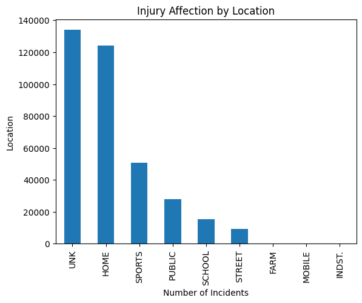

```python
# Categorizing race injury affection
location = (
    neiss_clean
    .value_counts('location_text')
    .reset_index(name = 'incident_count')
)

ax = (
    location.head(10)
    .plot(
    kind = 'bar',
    legend = False,
    x = 'location_text',
    y = 'incident_count'
    )
)

ax.set_title('Injury Affection by Location')
ax.set_xlabel('Number of Incidents')
ax.set_ylabel('Location')
```

Home-based injuries may require education, while public-space injuries suggest policy or infrastructure solutions.

We began this journey with a massive, cryptic substrate of over 360,000 emergency room records. In the R environment, we knew how to navigate these waters, but by transitioning to Python and the "Tidy" logic of Method Chaining, we’ve built something more robust: a forensic protocol for national safety.

What the Registry Revealed Our investigation moved past the "spectacular" hazards and uncovered a quieter, more systemic crisis. By auditing the NEISS-2024 data, we discovered:

The Culprits: It isn't chainsaws or fireworks—it's Floors and Beds.

The Context: Clinical narratives revealed a recurring cycle of frailty and falls within care facilities.

The Timing: Risk doesn't take the weekend off, peaking on Mondays and Sundays as our household rhythms shift.